# CRISP-DM Skills Check (Penguins)

Alona Lagodzia, Karoline Kiliyilathu, Julio Dinis

# 1 Executive summary

*This assignment examines whether the sex of Gentoo penguins can be predicted using physical measurements such as bill length, bill depth, flipper length, and body mass. After cleaning the dataset and removing missing values, a decision tree model was trained using an 80/20 train-test split. The model achieved an accuracy of 0.913 and an F1 score of 0.923, significantly outperforming a baseline of approximately 52%, with body mass and bill depth identified as the most important features. These results indicate that physical characteristics contain strong predictive information for distinguishing between male and female penguins. This suggests that even simple, interpretable models can effectively capture underlying biological differences.*

# 2 Framing the Problem

# 3 Data Understanding

```r
# Load data
data("penguins", package = "palmerpenguins")

# Shows only first 6 rows of the data frame
head(penguins)
```

```
## # A tibble: 6 × 8
##   species island    bill_length_mm bill_depth_mm flipper_length_mm body_mass_g
##   <fct>   <fct>              <dbl>         <dbl>             <int>       <int>
## 1 Adelie  Torgersen           39.1          18.7               181        3750
## 2 Adelie  Torgersen           39.5          17.4               186        3800
## 3 Adelie  Torgersen           40.3          18                 195        3250
## 4 Adelie  Torgersen           NA            NA                  NA          NA
## 5 Adelie  Torgersen           36.7          19.3               193        3450
## 6 Adelie  Torgersen           39.3          20.6               190        3650
## # ℹ 2 more variables: sex <fct>, year <int>
```

```r
# Number of rows and columns
dim(penguins)  # 344 rows and 8 columns
```

```
## [1] 344   8
```

```r
# Check the data formats
str(penguins)
```

```
## tibble [344 × 8] (S3: tbl_df/tbl/data.frame)
##  $ species          : Factor w/ 3 levels "Adelie","Chinstrap",..: 1 1 1 1 1 1 1 1 1 1 ...
##  $ island           : Factor w/ 3 levels "Biscoe","Dream",..: 3 3 3 3 3 3 3 3 3 3 ...
##  $ bill_length_mm   : num [1:344] 39.1 39.5 40.3 NA 36.7 39.3 38.9 39.2 34.1 42 ...
##  $ bill_depth_mm    : num [1:344] 18.7 17.4 18 NA 19.3 20.6 17.8 19.6 18.1 20.2 ...
##  $ flipper_length_mm: int [1:344] 181 186 195 NA 193 190 181 195 193 190 ...
##  $ body_mass_g      : int [1:344] 3750 3800 3250 NA 3450 3650 3625 4675 3475 4250 ...
##  $ sex              : Factor w/ 2 levels "female","male": 2 1 1 NA 1 2 1 2 NA NA ...
##  $ year             : int [1:344] 2007 2007 2007 2007 2007 2007 2007 2007 2007 2007 ...
```

```r
# Check for duplicated values
duplicated_rows <- duplicated(penguins)
# Print the result
if (any(duplicated_rows)) {
  print("There are duplicated rows.")
} else {
  print("No duplicated rows found.")
}
```

```
## [1] "No duplicated rows found."
```

```r
# Summary statistics
summary(penguins)
```

```
##       species          island    bill_length_mm  bill_depth_mm
##  Adelie   :152   Biscoe   :168   Min.   :32.10   Min.   :13.10
##  Chinstrap: 68   Dream    :124   1st Qu.:39.23   1st Qu.:15.60
##  Gentoo   :124   Torgersen: 52   Median :44.45   Median :17.30
##                                  Mean   :43.92   Mean   :17.15
##                                  3rd Qu.:48.50   3rd Qu.:18.70
##                                  Max.   :59.60   Max.   :21.50
##                                  NA's   :2       NA's   :2
##  flipper_length_mm  body_mass_g       sex           year
##  Min.   :172.0     Min.   :2700   female:165   Min.   :2007
##  1st Qu.:190.0     1st Qu.:3550   male  :168   1st Qu.:2007
##  Median :197.0     Median :4050   NA's  : 11   Median :2008
##  Mean   :200.9     Mean   :4202                Mean   :2008
##  3rd Qu.:213.0     3rd Qu.:4750                3rd Qu.:2009
##  Max.   :231.0     Max.   :6300                Max.   :2009
##  NA's   :2         NA's   :2
```

```r
#interactive spreadsheet-like display of the data frame in RStudio
# View(penguins)

# Calculate the count of missing values per column
missing_count <- colSums(is.na(penguins))
# Calculate the share of missing values per column
missing_share <- colMeans(is.na(penguins))
missing_summary <- data.frame(
        count = missing_count,
        share = round(missing_share, 4)
)
print(missing_summary)
```

```
##                   count  share
## species               0 0.0000
## island                0 0.0000
## bill_length_mm        2 0.0058
## bill_depth_mm         2 0.0058
## flipper_length_mm     2 0.0058
## body_mass_g           2 0.0058
## sex                  11 0.0320
## year                  0 0.0000
```

```r
# Class balance for our target population (Gentoo)
gentoo_overview <- penguins %>%
        filter(species == "Gentoo")
cat("Gentoo penguins:", nrow(gentoo_overview), "\n")
```

```
## Gentoo penguins: 124
```

```r
table(gentoo_overview$sex, useNA = "ifany")
```

```
##
## female   male   <NA>
##     58     61      5
```

# 4 Explorative Data Analysis

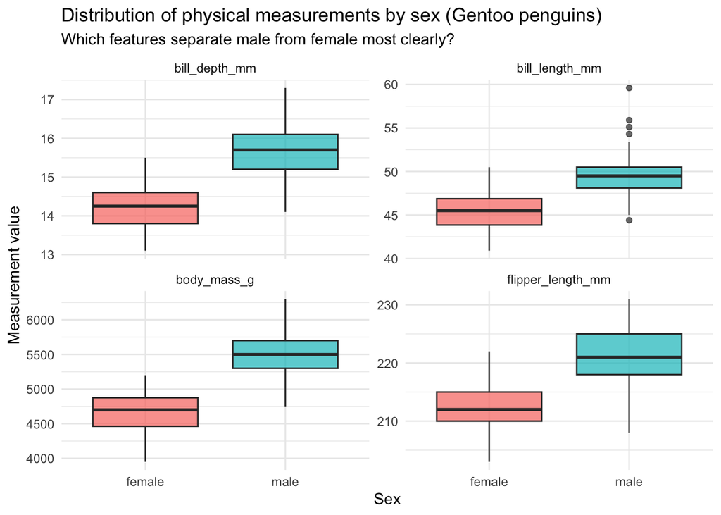

```r
# Filter to Gentoo, drop NAs for plotting only
gentoo_eda <- penguins %>%
        filter(species == "Gentoo") %>%
        drop_na()

# --- Plot 1: Distribution of all 4 numeric measurements by sex ---
gentoo_long <- gentoo_eda %>%
        select(sex, bill_length_mm, bill_depth_mm,
               flipper_length_mm, body_mass_g) %>%
        pivot_longer(cols = -sex,
                     names_to = "measurement",
                     values_to = "value")

ggplot(gentoo_long, aes(x = sex, y = value, fill = sex)) +
        geom_boxplot(alpha = 0.7) +
        facet_wrap(~ measurement, scales = "free_y") +
        labs(title = "Distribution of physical measurements by sex (Gentoo penguins)",
             subtitle = "Which features separate male from female most clearly?",
             x = "Sex",
             y = "Measurement value") +
        theme_minimal() +
        theme(legend.position = "none")
```

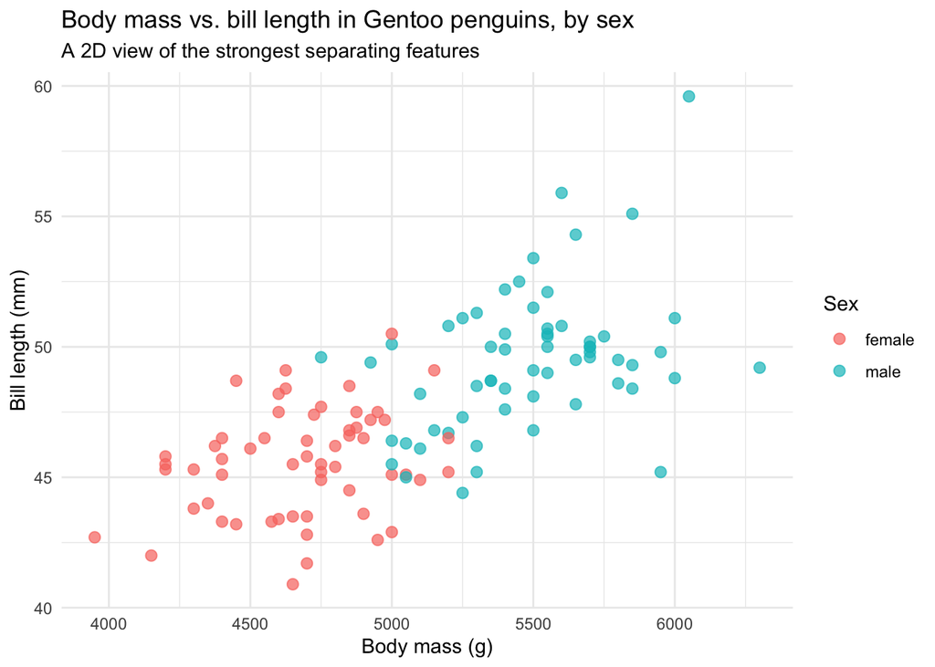

```r
# --- Plot 2: Relationship between two key features, colored by sex ---
ggplot(gentoo_eda, aes(x = body_mass_g, y = bill_length_mm, color = sex)) +
        geom_point(size = 2.5, alpha = 0.7) +
        labs(title = "Body mass vs. bill length in Gentoo penguins, by sex",
             subtitle = "A 2D view of the strongest separating features",
             x = "Body mass (g)",
             y = "Bill length (mm)",
             color = "Sex") +
        theme_minimal()
```

# 5 Data Preparation

```r
# Filter to Gentoo, drop incomplete rows
gentoo_clean <- penguins %>%
        filter(species == "Gentoo") %>%
        drop_na()

# ensure categorical variables are factors
is.factor(gentoo_clean$sex)
```

```
## [1] TRUE
```

```r
is.factor(gentoo_clean$species)
```

```
## [1] TRUE
```

```r
is.factor(gentoo_clean$island)
```

```
## [1] TRUE
```

```r
# Verification of the cleaned dataset
dim(gentoo_clean)
```

```
## [1] 119   8
```

```r
table(gentoo_clean$sex)
```

```
##
## female   male
##     58     61
```

```r
summary(gentoo_clean)
```

```
##       species          island    bill_length_mm  bill_depth_mm
##  Adelie   :  0   Biscoe   :119   Min.   :40.90   Min.   :13.10
##  Chinstrap:  0   Dream    :  0   1st Qu.:45.35   1st Qu.:14.20
##  Gentoo   :119   Torgersen:  0   Median :47.40   Median :15.00
##                                  Mean   :47.57   Mean   :15.00
##                                  3rd Qu.:49.60   3rd Qu.:15.75
##                                  Max.   :59.60   Max.   :17.30
##  flipper_length_mm  body_mass_g       sex          year
##  Min.   :203.0     Min.   :3950   female:58   Min.   :2007
##  1st Qu.:212.0     1st Qu.:4700   male  :61   1st Qu.:2007
##  Median :216.0     Median :5050               Median :2008
##  Mean   :217.2     Mean   :5092               Mean   :2008
##  3rd Qu.:221.5     3rd Qu.:5500               3rd Qu.:2009
##  Max.   :231.0     Max.   :6300               Max.   :2009
```

*We restrict the dataset to Gentoo penguins (the population of our research question) and drop rows with any missing values, leaving 119 complete observations. Categorical variables (sex, species, island) are converted to factors so they can be used directly by the decision-tree model. Imputation is not used: missingness is small (~4% of Gentoos), and simple deletion is more transparent and avoids introducing assumptions.*

# 6 Modeling

## 6.1 Classification

```r
# Select target and predictor variables
model_data <- gentoo_clean %>%
        select(sex, bill_length_mm, bill_depth_mm, flipper_length_mm, body_mass_g)

# Stratified 80/20 train-test split
split_index <- createDataPartition(model_data$sex, p = 0.8, list = FALSE)

train_data <- model_data[split_index, ]
test_data  <- model_data[-split_index, ]

# Verify split and class balance
dim(train_data)
```

```
## [1] 96  5
```

```r
dim(test_data)
```

```
## [1] 23  5
```

```r
table(train_data$sex)
```

```
##
## female   male
##     47     49
```

```r
table(test_data$sex)
```

```
##
## female   male
##     11     12
```

```r
# Majority-class baseline
baseline_class <- names(which.max(table(train_data$sex)))
baseline_accuracy <- mean(test_data$sex == baseline_class)

cat("Majority-class baseline accuracy:", round(baseline_accuracy, 3), "\n")
```

```
## Majority-class baseline accuracy: 0.522
```

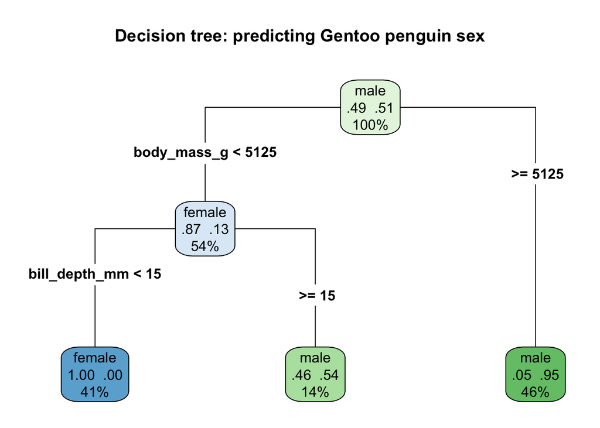

```r
# Fit decision tree model
tree_model <- rpart(
        sex ~ bill_length_mm + bill_depth_mm + flipper_length_mm + body_mass_g,
        data = train_data,
        method = "class"
)

# Visualize the decision tree
rpart.plot(
        tree_model,
        type = 4,
        extra = 104,
        main = "Decision tree: predicting Gentoo penguin sex"
)
```

```r
# Predict on test set
test_preds <- predict(tree_model, newdata = test_data, type = "class")

# Confusion matrix
cm <- confusionMatrix(test_preds, test_data$sex, positive = "male")
cm
```

```
## Confusion Matrix and Statistics
##
##           Reference
## Prediction female male
##     female      9    0
##     male        2   12
##
##                Accuracy : 0.913
##                  95% CI : (0.7196, 0.9893)
##     No Information Rate : 0.5217
##     P-Value [Acc > NIR] : 7.445e-05
##
##                   Kappa : 0.8244
##
##  Mcnemar's Test P-Value : 0.4795
##
##             Sensitivity : 1.0000
##             Specificity : 0.8182
##          Pos Pred Value : 0.8571
##          Neg Pred Value : 1.0000
##              Prevalence : 0.5217
##          Detection Rate : 0.5217
##    Detection Prevalence : 0.6087
##       Balanced Accuracy : 0.9091
##
##        'Positive' Class : male
##
```

```r
# Extract metrics
accuracy <- cm$overall["Accuracy"]
f1_score <- cm$byClass["F1"]

cat("Test accuracy:", round(accuracy, 3), "\n")
```

```
## Test accuracy: 0.913
```

```r
cat("F1 score:", round(f1_score, 3), "\n")
```

```
## F1 score: 0.923
```

```r
# Feature importance
tree_model$variable.importance
```

```
##       body_mass_g     bill_depth_mm    bill_length_mm flipper_length_mm
##          33.35033          25.31819          22.86061          19.21906
```

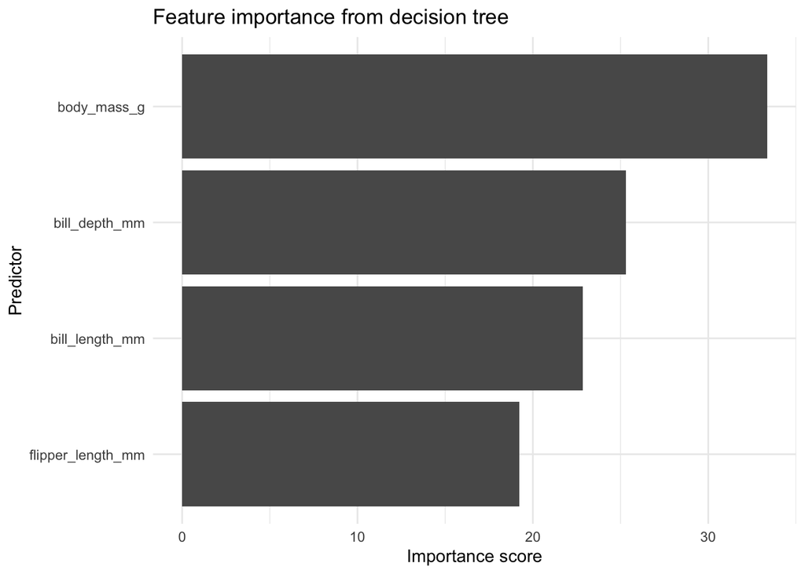

```r
importance_df <- data.frame(
        variable = names(tree_model$variable.importance),
        importance = as.numeric(tree_model$variable.importance)
)

ggplot(importance_df, aes(x = reorder(variable, importance), y = importance)) +
        geom_col() +
        coord_flip() +
        labs(
                title = "Feature importance from decision tree",
                x = "Predictor",
                y = "Importance score"
        ) +
        theme_minimal()
```

*The model is a decision tree trained on 80% of the cleaned Gentoo dataset and evaluated on the remaining 20%. Accuracy is used as the primary metric because the classes are approximately balanced, while F1-score is included as a robustness check.*

# 7 Evaluation & Validation

- **Metric:** *The model achieves an accuracy of 0.913 and an F1 score of 0.923 on the test set, clearly outperforming the baseline accuracy of approximately 0.52.*
- **Interpretation:** *The model performs well on a balanced test set (11 female, 12 male), correctly classifying all male penguins and misclassifying only 2 female penguins. Feature importance shows that body mass (33.35) and bill depth (25.32) are the most influential predictors, consistent with patterns observed in the EDA. These results indicate that the model captures the main structure of the data. A limitation is the small test set (23 observations), so results should be interpreted as an estimate rather than a definitive measure.*

# 8 AI Assistance

- **Tools used:** *Claude Opus 4.7 Adaptive; GitHub Copilot (GPT-5.2-Codex); Chat GPT*
- **One prompt:** *We are using the Palmer Penguins dataset for a Fundamentals of Data Science homework. Our question is whether physical measurements can predict the sex of Gentoo penguins. Help us implement a simple decision tree model in R with an 80/20 train-test split, confusion matrix, accuracy, F1 score, and feature importance.*
- **How validated:** *We validated the AI-assisted code and text by running the full R Markdown file without errors, checking that the 80/20 train-test split preserved class balance, comparing the model accuracy to a majority-class baseline, and inspecting the confusion matrix. We also checked that the feature importance results were consistent with the EDA plots, especially the visible separation by body mass and bill depth. In addition, AI tools were used for rephrasing, grammar correction, and improving the clarity and consistency of the written text. All AI-assisted content was manually reviewed to ensure it accurately reflects the analysis results and aligns with the assignment requirements and lecture material.*